# A7: Kickstarter

Author

Gabriel Kan

Published

February 27, 2026

## Loading Libraries

Make sure to load all the libraries:

- dplyr
- ggplot2
- Any other libraries you want

*Note: You can add the comment `#| warning: false` to the top of your code block to hide the output from loading the libraries.*

```r
library(dplyr)
library(ggplot2)
```

## Loading Data

```r
ks_2018_df <-read.csv("ks-projects-201801.csv")
glimpse(ks_2018_df)
```

```
Rows: 378,661
Columns: 15
$ ID               <int> 1000002330, 1000003930, 1000004038, 1000007540, 10000…
$ name             <chr> "The Songs of Adelaide & Abullah", "Greeting From Ear…
$ category         <chr> "Poetry", "Narrative Film", "Narrative Film", "Music"…
$ main_category    <chr> "Publishing", "Film & Video", "Film & Video", "Music"…
$ currency         <chr> "GBP", "USD", "USD", "USD", "USD", "USD", "USD", "USD…
$ deadline         <chr> "2015-10-09", "2017-11-01", "2013-02-26", "2012-04-16…
$ goal             <dbl> 1000, 30000, 45000, 5000, 19500, 50000, 1000, 25000, …
$ launched         <chr> "2015-08-11 12:12:28", "2017-09-02 04:43:57", "2013-0…
$ pledged          <dbl> 0.00, 2421.00, 220.00, 1.00, 1283.00, 52375.00, 1205.…
$ state            <chr> "failed", "failed", "failed", "failed", "canceled", "…
$ backers          <int> 0, 15, 3, 1, 14, 224, 16, 40, 58, 43, 0, 100, 0, 0, 7…
$ country          <chr> "GB", "US", "US", "US", "US", "US", "US", "US", "US",…
$ usd.pledged      <dbl> 0.00, 100.00, 220.00, 1.00, 1283.00, 52375.00, 1205.0…
$ usd_pledged_real <dbl> 0.00, 2421.00, 220.00, 1.00, 1283.00, 52375.00, 1205.…
$ usd_goal_real    <dbl> 1533.95, 30000.00, 45000.00, 5000.00, 19500.00, 50000…
```

## Processing Data

```r
ks_2018_df <- ks_2018_df |>
  mutate(
    deadline_date = as.Date(deadline),
    launched_date = as.Date(launched)
  )
ks_2018_df <- ks_2018_df |>
  mutate(
    deadline_year = format(deadline_date,"%Y"),
    launched_year = format(launched_date, "%Y")
  )
glimpse(ks_2018_df)
```

```
Rows: 378,661
Columns: 19
$ ID               <int> 1000002330, 1000003930, 1000004038, 1000007540, 10000…
$ name             <chr> "The Songs of Adelaide & Abullah", "Greeting From Ear…
$ category         <chr> "Poetry", "Narrative Film", "Narrative Film", "Music"…
$ main_category    <chr> "Publishing", "Film & Video", "Film & Video", "Music"…
$ currency         <chr> "GBP", "USD", "USD", "USD", "USD", "USD", "USD", "USD…
$ deadline         <chr> "2015-10-09", "2017-11-01", "2013-02-26", "2012-04-16…
$ goal             <dbl> 1000, 30000, 45000, 5000, 19500, 50000, 1000, 25000, …
$ launched         <chr> "2015-08-11 12:12:28", "2017-09-02 04:43:57", "2013-0…
$ pledged          <dbl> 0.00, 2421.00, 220.00, 1.00, 1283.00, 52375.00, 1205.…
$ state            <chr> "failed", "failed", "failed", "failed", "canceled", "…
$ backers          <int> 0, 15, 3, 1, 14, 224, 16, 40, 58, 43, 0, 100, 0, 0, 7…
$ country          <chr> "GB", "US", "US", "US", "US", "US", "US", "US", "US",…
$ usd.pledged      <dbl> 0.00, 100.00, 220.00, 1.00, 1283.00, 52375.00, 1205.0…
$ usd_pledged_real <dbl> 0.00, 2421.00, 220.00, 1.00, 1283.00, 52375.00, 1205.…
$ usd_goal_real    <dbl> 1533.95, 30000.00, 45000.00, 5000.00, 19500.00, 50000…
$ deadline_date    <date> 2015-10-09, 2017-11-01, 2013-02-26, 2012-04-16, 2015…
$ launched_date    <date> 2015-08-11, 2017-09-02, 2013-01-12, 2012-03-17, 2015…
$ deadline_year    <chr> "2015", "2017", "2013", "2012", "2015", "2016", "2014…
$ launched_year    <chr> "2015", "2017", "2013", "2012", "2015", "2016", "2014…
```

### Initial Calculations

```r
num_projects <- nrow(ks_2018_df)
num_success <- ks_2018_df |>
  filter(state == "successful") |>
  nrow()
num_fail <- ks_2018_df |>
  filter(state == "failed") |>
  nrow()
per_fail <- num_fail / num_projects * 100
```

There are 378661 projects in the dataset. Of these, 133956 projects are marked as successful, while 197719 projects are marked as failed. This means that approximately 52.2% of the projects in the dataset are classified as failed.

### Biggest Non-Success

```r
biggest_non_success <- ks_2018_df |>
  filter(state != "successful") |>
  filter(usd_pledged_real == max(usd_pledged_real))
```

Skarp Technologies popularized their “Skarp Laser Razor: 21st Century Shaving”, and was a razor company that got suspended by Kickstarter for violating their rules in 2015.

### Project State

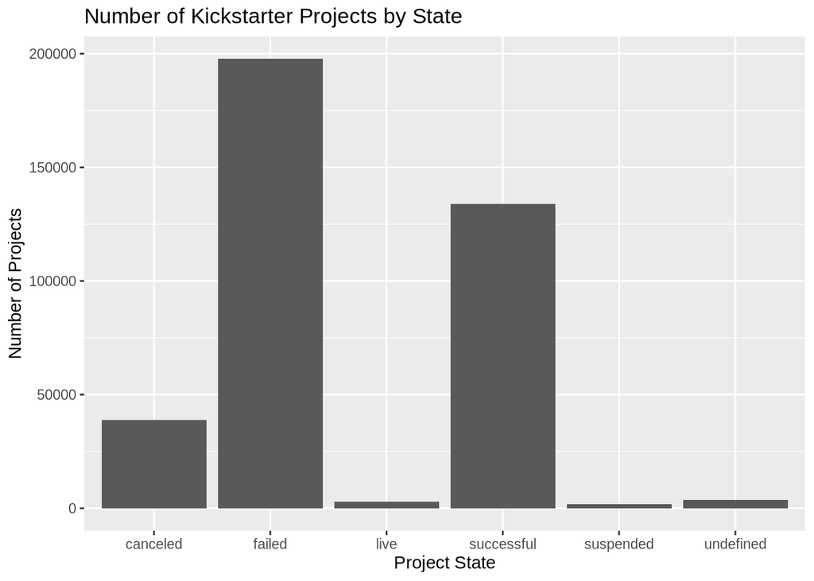

```r
state_summary_df <- ks_2018_df |>
  group_by(state) |>
  summarize(project_count = n())

ggplot(state_summary_df, aes(x = state, y = project_count)) +
  geom_col() +
  labs(
    title = "Number of Kickstarter Projects by State",
    x = "Project State",
    y = "Number of Projects"
  )
```

A majority of Kickstarters end in failures (~50%), while about 30% end up successful. There are 6 categories for the results of a kickstarter.

### Yearly Summary

```r
year_summary_df <- ks_2018_df |>
  group_by(launched_year) |>
  summarise(
    count = n(),
    successful_projects = sum(state == "successful"),
    percent_success = successful_projects / count * 100,
    avg_pledged = mean(usd_pledged_real, na.rm = TRUE)
  )
print(year_summary_df)
```

```
# A tibble: 11 × 5
   launched_year count successful_projects percent_success avg_pledged
   <chr>         <int>               <int>           <dbl>       <dbl>
 1 1970              7                   0             0            0
 2 2009           1329                 579            43.6       2141.
 3 2010          10519                4593            43.7       2800.
 4 2011          26237               12171            46.4       3954.
 5 2012          41165               17892            43.5       7833.
 6 2013          44851               19415            43.3      10670.
 7 2014          67745               21107            31.2       7744.
 8 2015          77300               20971            27.1       8895.
 9 2016          57184               18766            32.8      11488.
10 2017          52200               18462            35.4      11954.
11 2018            124                   0             0          510.
```

I used launched year, but that was just a random decision. For percent_success, I dictacted success as only the projects that were labelled “successful” and compared it with the number of total projects because it is the most intuitive version of what counts as percent success. I just chose the mean of all the pledged amounts as the variable avg_pledged because I think it tells a story about the data, and we can assume a general trend with the pledge amounts.

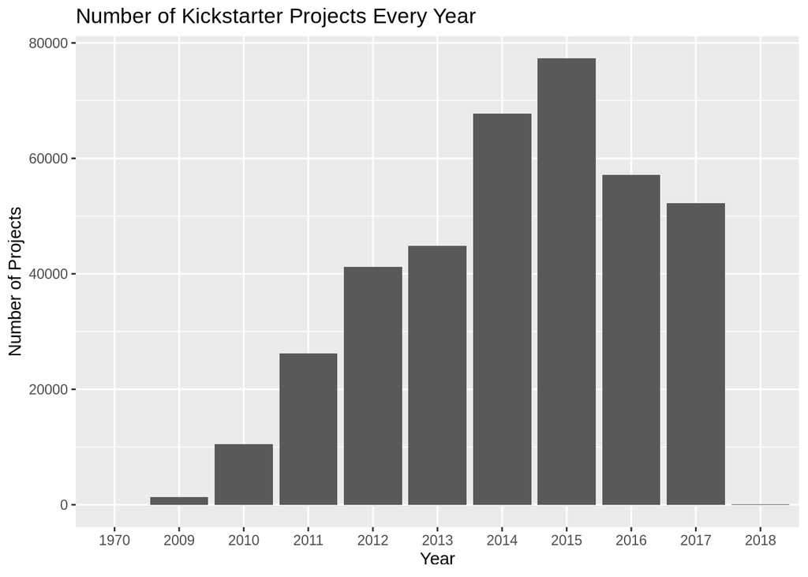

```r
library(ggplot2)

ggplot(year_summary_df,
       aes(x = launched_year, y = count)) +
  geom_col() +
  labs(
    title = "Number of Kickstarter Projects Every Year",
    x = "Year",
    y = "Number of Projects"
  )
```

### Unusual data values

For some reason, there is one column for 1970 that has no data points shown in the graph. When I looked through the year_summary_df for those years, it shows that for some reason there is a row for 1970, with 7 count, and 0 everything else. This could represent missing or corrupted data.

I would ask if the 1970 data values were supposed to mean anything, maybe placeholder values?